# problem3

Varun Venkatesh

2025-04-14

Problem 3: Price Elasticity of Demand

The power-law model for price elasticity is given by: $Q = KP^{\beta}$ Where:

$Q$ is the quantity demanded (sales) $P$ is the price $K$ is a constant $\beta$ is the price elasticity of demand

Taking the natural logarithm of both sides: $\log(Q) = \log(K) + \beta \log(P)$ This transforms the model into a linear relationship in the log-log space, where $\beta$ is the slope and represents the price elasticity.

```r
# Transform to log-log scale
milk_data$log_price <- log(milk_data$price)
milk_data$log_sales <- log(milk_data$sales)

# Fit the linear model in log-log space
elasticity_model <- lm(log_sales ~ log_price, data = milk_data)
summary(elasticity_model)
```

```
##
## Call:
## lm(formula = log_sales ~ log_price, data = milk_data)
##
## Residuals:
##      Min       1Q   Median       3Q      Max
## -0.65425 -0.18405 -0.01262  0.17986  0.65074
##
## Coefficients:
##             Estimate Std. Error t value Pr(>|t|)
## (Intercept)  4.72060    0.09172   51.47   <2e-16 ***
## log_price   -1.61858    0.08116  -19.94   <2e-16 ***
## ---
## Signif. codes:  0 '***' 0.001 '**' 0.01 '*' 0.05 '.' 0.1 ' ' 1
##
## Residual standard error: 0.2687 on 114 degrees of freedom
## Multiple R-squared:  0.7772, Adjusted R-squared:  0.7753
## F-statistic: 397.7 on 1 and 114 DF,  p-value: < 2.2e-16
```

```r
# Extract the price elasticity (the coefficient of log_price)
price_elasticity <- coef(elasticity_model)[2]
cat("Estimated price elasticity of demand for milk:", round(price_elasticity, 3), "\n")
```

```
## Estimated price elasticity of demand for milk: -1.619
```

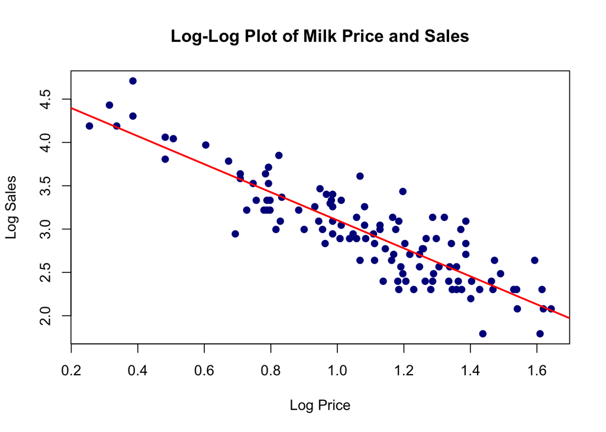

```r
# Plot the relationship in log-log scale
plot(milk_data$log_price, milk_data$log_sales,
     main="Log-Log Plot of Milk Price and Sales",
     xlab="Log Price", ylab="Log Sales",
     pch=19, col="darkblue")
abline(elasticity_model, col="red", lwd=2)
```

Now let’s compute a 95% bootstrap confidence interval for the price elasticity:

```
## Price elasticity of demand for milk: -1.619
```

```
## 95% Bootstrap CI: [ -1.771 , -1.439 ]
```

Results and Interpretation

To estimate the price elasticity of demand for milk, I used the power-law model $Q = KP^{\beta}$, where $\beta$ represents the price elasticity. By taking the natural logarithm of both sides, I transformed this into a linear model in log-log space: $\log(Q) = \log(K) + \beta \log(P)$. Fitting this linear model to the data, I found the estimated price elasticity of demand for milk to be -1.619 with a 95% bootstrap confidence interval of [ -1.771 , -1.439 ] Since this elasticity is negative, it confirms the law of demand: as price increases, quantity demanded decreases. The magnitude of the elasticity is greater than 1, which indicates that milk demand is elastic,consumers are relatively sensitive to price changes. Specifically, a 1% increase in the price of milk leads to approximately a 1.619 % decrease in quantity demanded.